# Math 189 Homework 2: Exploratory Data Analysis of mtcars

Yunchun Pan, Siqing Lyu, Nathan Ng, Pudan Xu

1/8/2021

## Introduction

In this homework, we examine the Motor Trend Car Road Tests dataset **mtcars.csv**[^1]. The file contains data extracted from the 1974 Motor Trend US magazine, and comprises fuel consumption and 10 aspects of automobile design and performance for 32 automobiles (1973–74 models). The following variables were measured:

- **mpg**: Miles per gallon
- **cyl**: Number of cylinders
- **disp**: Displacement(cubic inch)
- **hp**: Gross horsepower
- **drat**: Rear axle ratio
- **wt**: Weight
- **qsec**: 1/4 mile time
- **vs**: Engine (0 = V-shaped, 1 = straight)
- **am**: Transmission (0 = automatic, 1 = manual)
- **gear**: Number of forward gears
- **carb**: Number of carburetors

## Our Work

We first load the Motor Trend Car Road Tests dataset into R to get the data we use throughout this assignment.

```r
mtcars <- read.csv("~/Desktop/ma189/Data/mtcars.csv")
```

After we load in our dataset, we calculate sample mean and sample variance of each variable and store them into matrices to be $M_m$ and $M_{v}$ respectively.

```r
ncols = dim(mtcars)[2]
varMean <- colMeans(mtcars[,2:ncols])
Mm <-t(as.matrix(varMean))
Mm <- Mm[1,]
Mm
```

```
##        mpg        cyl       disp         hp       drat         wt       qsec
##  20.090625   6.187500 230.721875 146.687500   3.596563   3.217250  17.848750
##         vs         am       gear       carb
##   0.437500   0.406250   3.687500   2.812500
```

```r
Mv <- Mm
for (i in 2:dim(mtcars)[2]) {
  Mv[i-1] = var(mtcars[,i])
}
Mv
```

```
##          mpg          cyl         disp           hp         drat           wt
## 3.632410e+01 3.189516e+00 1.536080e+04 4.700867e+03 2.858814e-01 9.573790e-01
##         qsec           vs           am         gear         carb
## 3.193166e+00 2.540323e-01 2.489919e-01 5.443548e-01 2.608871e+00
```

Calculate the sample variance-covariance matrix and the sample correlation matrix and store the result into matrices $M_{vc}$ and $M_{cor}$ respectively.

```r
Mvc <- var(mtcars[,2:ncols])
Mvc
```

```
##              mpg         cyl        disp          hp         drat          wt
## mpg    36.324103  -9.1723790  -633.09721 -320.732056   2.19506351  -5.1166847
## cyl    -9.172379   3.1895161   199.66028  101.931452  -0.66836694   1.3673710
## disp -633.097208 199.6602823 15360.79983 6721.158669 -47.06401915 107.6842040
## hp   -320.732056 101.9314516  6721.15867 4700.866935 -16.45110887  44.1926613
## drat    2.195064  -0.6683669   -47.06402  -16.451109   0.28588135  -0.3727207
## wt     -5.116685   1.3673710   107.68420   44.192661  -0.37272073   0.9573790
## qsec    4.509149  -1.8868548   -96.05168  -86.770081   0.08714073  -0.3054816
## vs      2.017137  -0.7298387   -44.37762  -24.987903   0.11864919  -0.2736613
## am      1.803931  -0.4657258   -36.56401   -8.320565   0.19015121  -0.3381048
## gear    2.135685  -0.6491935   -50.80262   -6.358871   0.27598790  -0.4210806
## carb   -5.363105   1.5201613    79.06875   83.036290  -0.07840726   0.6757903
##              qsec           vs           am        gear        carb
## mpg    4.50914919   2.01713710   1.80393145   2.1356855 -5.36310484
## cyl   -1.88685484  -0.72983871  -0.46572581  -0.6491935  1.52016129
## disp -96.05168145 -44.37762097 -36.56401210 -50.8026210 79.06875000
## hp   -86.77008065 -24.98790323  -8.32056452  -6.3588710 83.03629032
## drat   0.08714073   0.11864919   0.19015121   0.2759879 -0.07840726
## wt    -0.30548161  -0.27366129  -0.33810484  -0.4210806  0.67579032
## qsec   3.19316613   0.67056452  -0.20495968  -0.2804032 -1.89411290
## vs     0.67056452   0.25403226   0.04233871   0.0766129 -0.46370968
## am    -0.20495968   0.04233871   0.24899194   0.2923387  0.04637097
## gear  -0.28040323   0.07661290   0.29233871   0.5443548  0.32661290
## carb  -1.89411290  -0.46370968   0.04637097   0.3266129  2.60887097
```

```r
Mcor <- cor(mtcars[,2:ncols])
Mcor
```

```
##             mpg        cyl       disp         hp        drat         wt
## mpg   1.0000000 -0.8521620 -0.8475514 -0.7761684  0.68117191 -0.8676594
## cyl  -0.8521620  1.0000000  0.9020329  0.8324475 -0.69993811  0.7824958
## disp -0.8475514  0.9020329  1.0000000  0.7909486 -0.71021393  0.8879799
## hp   -0.7761684  0.8324475  0.7909486  1.0000000 -0.44875912  0.6587479
## drat  0.6811719 -0.6999381 -0.7102139 -0.4487591  1.00000000 -0.7124406
## wt   -0.8676594  0.7824958  0.8879799  0.6587479 -0.71244065  1.0000000
## qsec  0.4186840 -0.5912421 -0.4336979 -0.7082234  0.09120476 -0.1747159
## vs    0.6640389 -0.8108118 -0.7104159 -0.7230967  0.44027846 -0.5549157
## am    0.5998324 -0.5226070 -0.5912270 -0.2432043  0.71271113 -0.6924953
## gear  0.4802848 -0.4926866 -0.5555692 -0.1257043  0.69961013 -0.5832870
## carb -0.5509251  0.5269883  0.3949769  0.7498125 -0.09078980  0.4276059
##             qsec         vs          am       gear        carb
## mpg   0.41868403  0.6640389  0.59983243  0.4802848 -0.55092507
## cyl  -0.59124207 -0.8108118 -0.52260705 -0.4926866  0.52698829
## disp -0.43369788 -0.7104159 -0.59122704 -0.5555692  0.39497686
## hp   -0.70822339 -0.7230967 -0.24320426 -0.1257043  0.74981247
## drat  0.09120476  0.4402785  0.71271113  0.6996101 -0.09078980
## wt   -0.17471588 -0.5549157 -0.69249526 -0.5832870  0.42760594
## qsec  1.00000000  0.7445354 -0.22986086 -0.2126822 -0.65624923
## vs    0.74453544  1.0000000  0.16834512  0.2060233 -0.56960714
## am   -0.22986086  0.1683451  1.00000000  0.7940588  0.05753435
## gear -0.21268223  0.2060233  0.79405876  1.0000000  0.27407284
## carb -0.65624923 -0.5696071  0.05753435  0.2740728  1.00000000
```

We first draw a scatter plot of weights of automobiles and their mileage per gallon. This plot shows a negative association between these two variables. As automobile weight increases, its mileage per gallon decreases. The range of automobile weights is approximately 4, while the range of mileage per gallon is 23.5. There are three heavier automobiles in the dataset, and their data points are shown in the lower right corner of the plot.

```r
diff(range(mtcars$wt))
```

```
## [1] 3.911
```

```r
diff(range(mtcars$mpg))
```

```
## [1] 23.5
```

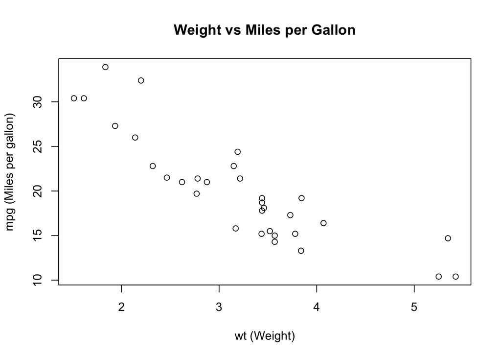

```r
plot(x = mtcars$wt, y = mtcars$mpg,
     xlab = "wt (Weight)", ylab = "mpg (Miles per gallon)",
     main = "Weight vs Miles per Gallon")
```

In addition, we apply log transformation of wt and mpg and create a scatter plot of log-transformed values. This plot shows that the log transformed weights and mileage per gallon have a more linear negative relationship than original weights and mpg. The variance of these transformed data points is smaller than that of original ones.

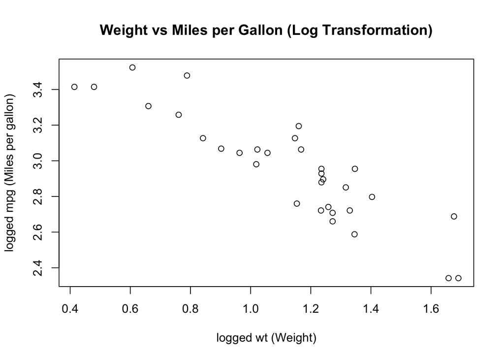

```r
x <- log(mtcars[,c("wt","mpg")])
plot(x[,1],x[,2],xlab = "logged wt (Weight)", ylab = "logged mpg (Miles per gallon)",
     main = "Weight vs Miles per Gallon (Log Transformation)")
```

Then, we use a 3D scatter plot to show the relationship between wt (Weight), mpg (Miles per gallon) and cyl (Number of cylinders) of automobiles. When we plot the three variables against each other, the data is split into three distinct clusters based on the number of cylinders. This includes automobiles with 4, 6, and 8 cylinders, which isn’t surprising since these are the most common number of cylinders found in automobiles. There is also a similar relationship between weight and mpg that is shared by the three clusters, where the greater the weight of an automobile, the lower the mpg. This is the same relationship we saw in our 2D previous scatter plot of weight and mpg for all observations.

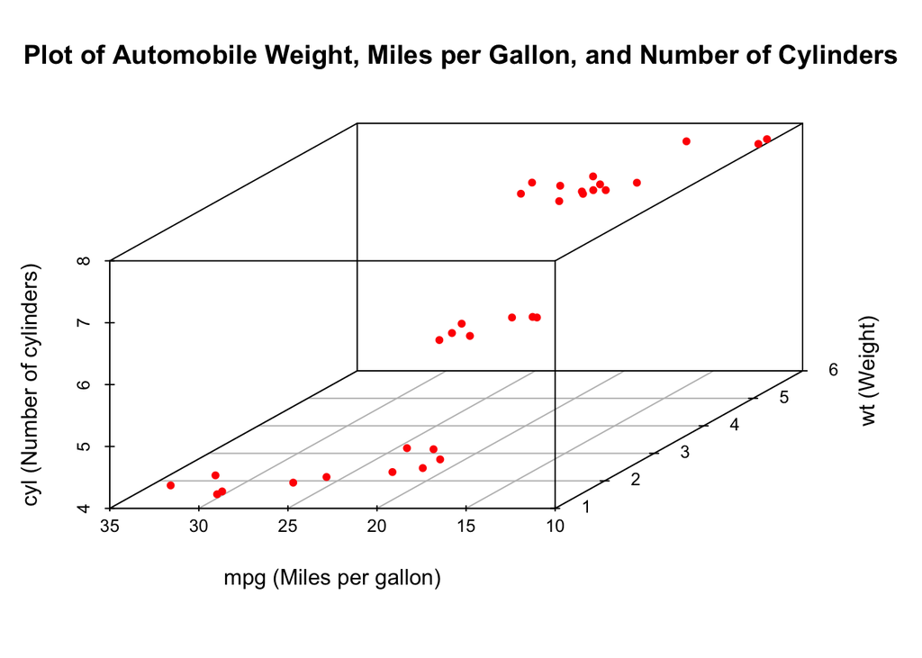

```r
library("scatterplot3d")
scatterplot3d(x = mtcars$wt, y = mtcars$mpg, z = mtcars$cyl,
              xlab = "wt (Weight)", ylab = "mpg (Miles per gallon)",
              zlab = "cyl (Number of cylinders)",
              main = "Plot of Automobile Weight, Miles per Gallon, and Number of Cylinders",
              color="red", pch=20, angle=220)
```

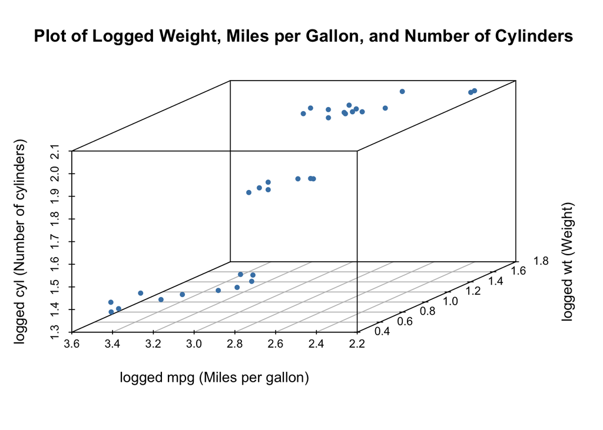

```r
scatterplot3d(x = log(mtcars$wt), y = log(mtcars$mpg), z = log(mtcars$cyl),
              xlab = "logged wt (Weight)", ylab = "logged mpg (Miles per gallon)",
              zlab = "logged cyl (Number of cylinders)",
              main = " Plot of Logged Weight, Miles per Gallon, and Number of Cylinders",
              color="steelblue", pch=20, angle=220)
```

Here, we draw pairwise scatter plots for all variables. Since the first column of mtcars dataset contains automobiles’ names and they are not quantitative data, we ignore the first column and make pairwise graphs of the other 11 columns. From the matrix graph below, we find that paired scatterplots for disp, hp, drat, gear, and carb are skewed, while plots of mpg vs wt and mpg vs qsec are approximately normal.

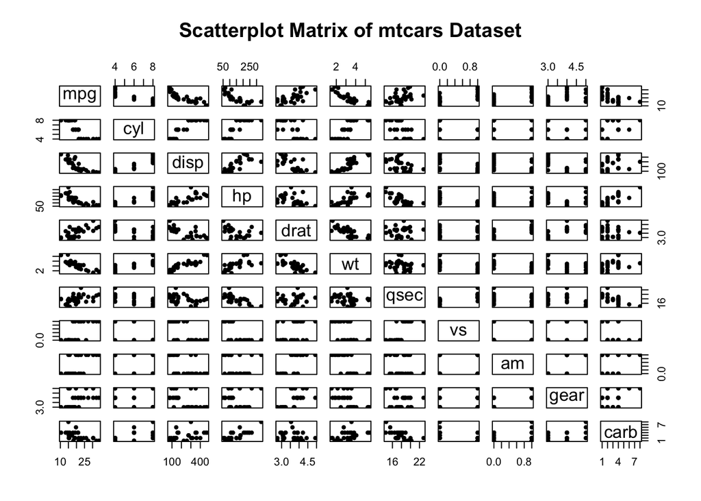

```r
ncols = dim(mtcars)[2]
pairs(mtcars[,2:ncols], pch=20, main="Scatterplot Matrix of mtcars Dataset")
```

**Optional: Appendix**

[^1]: Source: The Motor Trend automobiles data are presented in *Building Multiple Regression Models Interactively* from *Biometrics* by Harold V. Henderson and Paul F. Velleman (1981).